```python
# pip install birdnet
```

```python
import os # Interoperable file paths
from pathlib import Path

# Data Tools
import geopandas as gpd
import pandas as pd

# Visualization Tools
import holoviews as hv
import hvplot.pandas

# BirdNET Package
from birdnet import (SpeciesPredictions,
                     predict_species_within_audio_file,
                     predict_species_within_audio_files_mp,
                     predict_species_at_location_and_time)
```

```python
# Establish Data Directory
data_dir = os.path.join(
    '..',
    'data',
    'raw'
)
os.makedirs(data_dir, exist_ok=True)
```

# Birds and Wildfire

Wildfire is a key driver of the ecological dynamics of western North American forests. The severity of the burn dictates the state of the vegetation post-burn, with a high severity burn virtually resetting a landscape to an early seral stage. Since birds depend on specific vegetation for their nesting and foraging strategies, [large high-severity burns will reduce bird biodiversity within these sites](https://onlinelibrary.wiley.com/doi/10.1111/ddi.13281). On the other hand, a burn that is pyrodiverse--varying in burn severity like a patchwork--[promotes bird diversity during the years following a burn](https://research.fs.usda.gov/treesearch/53154). [Shrub-nesting and ground-foraging species enjoy more opportunities from the openings that wildfire can create, while cavity-nesting species are provided with snags from trees killed by fire. Canopy-nesting birds however, see a reduction in resources when trees are killed by high-severity fires](https://esajournals.onlinelibrary.wiley.com/doi/full/10.1002/ecs2.1346). Because birds are responsive to changes in landscape based on burn severity, they serve as great study subjects to assess forest management plans aimed at biological conservation.

### Acoustic Monitoring

In addition to being great indicators of effective forest management, birds are also easy to study! They don't require specialized equipment for boots-on-the-ground surveys, but advancements in acoustic monitoring have allowed researchers to reach further with their data collection. Acoustic monitors are placed into the field for weeks at a time to record the sounds of the environment. The recordings can then be processed through [BirdNET](https://birdnet.cornell.edu/), an artificial neural network that allows a computer to identify birds by sound. This project is supporting Leah McTique of Colorado State University and Zachary Steel of the US Forest Service Rocky Mountain Research Station as they look to assess changes to occupancy and biodiversity in relation to pyrodiversity. Their study sites are the sites of the 2020 Mullen, Cameron Peak, and East Troublesome mega-fires.

```python
# National Fire Occurrence Dataset 1984-2024
boundary_url = ("https://edcintl.cr.usgs.gov/downloads/sciweb1/shared/"
                "MTBS_Fire/data/composite_data/burned_area_extent_shapefile/"
                "mtbs_perimeter_data.zip")

# MTBS data directory
boundary_dir = os.path.join(data_dir, 'mtbs')
os.makedirs(boundary_dir, exist_ok=True)

boundary_path = os.path.join(boundary_dir, 'mtbs_bab.shp')

# Download once
if not os.path.exists(boundary_path):
    boundary_gdf = gpd.read_file(boundary_url)
    boundary_gdf = boundary_gdf[boundary_gdf.Incid_Name == 'CAMERON PEAK']
    boundary_gdf.to_file(boundary_path)

# Load from file
else:
    boundary_gdf = gpd.read_file(boundary_path)

# Generate site map
cpfire_map = boundary_gdf.hvplot(
    geo=True,
    tiles='EsriImagery',
    title=(f'{boundary_gdf.Incid_Name.values[0].title()} Wildfire'),
    alpha=0.4)

cpfire_map
```

[output not shown]

## Cameron Peak Wildfire of 2020

The audio used for this project were recorded within the burn area of the Cameron Peak wildfire. The Cameron Peak fire burned from August 13, 2020 until its full containment on December 2, 2020 when it became the largest wildifre in Colorado history. It burned 208,663 acres, led to the evacuation of over 20,000 people, and cost over $132 million to contain, with near $100 million in estimated damages. Burn area obtained from the [National - Burned Area Boundaries Dataset](https://www.mtbs.gov/product-descriptions)

### The Problem

While acoustic monitoring and artificial neural networks have taken care of a lot of the work to survey birds at the Cameron Peak site, the data still needs to be processed. The researchers have been tediously processing the files one by one into BirdNET analyzer. My goal is to provide an automated workflow, using python and the birdnet python package, to process large amounts of audio data into a usable CSV file for later analysis.

### Data Overview

Current resources available to me are a subset of 136 of the audio files from the research partner. The files are from four Cameron Peak sites, in .wav format, and each one hour long. The other critical resource is the source code and documentation of the [BirdNET GitHub page](https://github.com/birdnet-team/birdnet/tree/main).

## Project Approach: Exploring BirdNET Functions

### Prediction of Species Based on Location

Initially, I sought to familiarize myself with the capabilities of the birdnet python package. The easiest start to that was to use their function to generate a list of likely birds based on a given lat/lon value and time. I used the lat/lon, rounded to a whole number, of the Cameron Peak fire and did not specify a time.

```python
species_list = predict_species_at_location_and_time(
    40, -105
)
species_temp = []

for species, confidence in species_list.items():
    species_dict = {'Species': species,
         'Confidence': round(confidence, 2)}
    species_temp.append(species_dict)

species_location_df = pd.DataFrame(species_temp,
                                   columns=['Species', 'Confidence'])

species_location_df
```

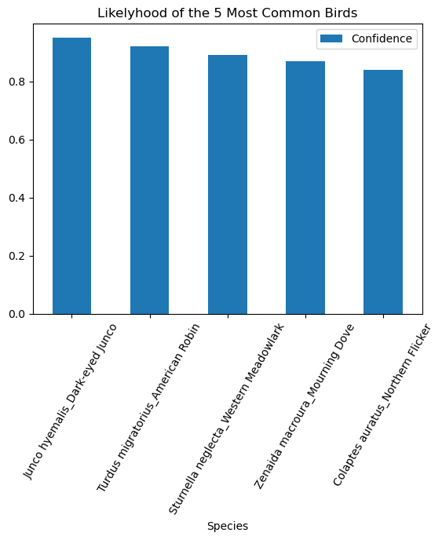

```python
species_location_df.head(5).plot.bar(x='Species', rot=60,
            title='Likelyhood of the 5 Most Common Birds')
```

From this chart, I can infer that the most likely bird encountered in this area is the Dark-eyed Junco. In hindsight, specifying a time may have given me a better picture of what may be found in the recordings.

### Prediction of Species Analyzed from a Single Audio File

Next was to test the BirdNET package's ability to predict the bird species present in a provided audio file.

```python
# predict species within the whole audio file
audio_path = Path("../data/raw/audio_data/CP1-007_20240701_193800.wav")

predictions = SpeciesPredictions(predict_species_within_audio_file(audio_path))

# View the structure of the results
predictions
```

[output not shown]

#### Success

The function returns a nested OrderedDict, with the time interval as the key and the species and confidence rating as the value. From here, we can loop through the OrderedDict to isolate the time, species, and confidence value. In the future, these values will be organized into rows of a CSV file, but for now we'll generate a print statement.

```python
# Loop through first tier OrderedDict
for time, pred_dict in list(predictions.items()):
    # Loop through second tier OrderedDict
    for prediction, confidence in pred_dict.items():
        print(f"{time}: Predicted {prediction}"
            f"with a confidence of {confidence:.2}")
```

```
(15.0, 18.0): Predicted Setophaga coronata_Yellow-rumped Warblerwith a confidence of 0.22
(15.0, 18.0): Predicted Setophaga nigrescens_Black-throated Gray Warblerwith a confidence of 0.14
(15.0, 18.0): Predicted Setophaga occidentalis_Hermit Warblerwith a confidence of 0.13
(21.0, 24.0): Predicted Buteo brachyurus_Short-tailed Hawkwith a confidence of 0.13
(42.0, 45.0): Predicted Setophaga magnolia_Magnolia Warblerwith a confidence of 0.67
(45.0, 48.0): Predicted Setophaga coronata_Yellow-rumped Warblerwith a confidence of 0.33
(69.0, 72.0): Predicted Setophaga nigrescens_Black-throated Gray Warblerwith a confidence of 0.25
(69.0, 72.0): Predicted Geothlypis philadelphia_Mourning Warblerwith a confidence of 0.2
(69.0, 72.0): Predicted Setophaga magnolia_Magnolia Warblerwith a confidence of 0.17
(72.0, 75.0): Predicted Setophaga nigrescens_Black-throated Gray Warblerwith a confidence of 0.18
(111.0, 114.0): Predicted Buteo brachyurus_Short-tailed Hawkwith a confidence of 0.16
(117.0, 120.0): Predicted Setophaga coronata_Yellow-rumped Warblerwith a confidence of 0.35
(117.0, 120.0): Predicted Setophaga nigrescens_Black-throated Gray Warblerwith a confidence of 0.26
(117.0, 120.0): Predicted Setophaga magnolia_Magnolia Warblerwith a confidence of 0.19
(138.0, 141.0): Predicted Strix uralensis_Ural Owlwith a confidence of 0.14
(153.0, 156.0): Predicted Melospiza lincolnii_Lincoln's Sparrowwith a confidence of 0.96
(159.0, 162.0): Predicted Turdus philomelos_Song Thrushwith a confidence of 0.17
(165.0, 168.0): Predicted Sayornis saya_Say's Phoebewith a confidence of 0.2
(171.0, 174.0): Predicted Turdus philomelos_Song Thrushwith a confidence of 0.12
(180.0, 183.0): Predicted Turdus migratorius_American Robinwith a confidence of 0.13
(186.0, 189.0): Predicted Setophaga nigrescens_Black-throated Gray Warblerwith a confidence of 0.95
(186.0, 189.0): Predicted Setophaga occidentalis_Hermit Warblerwith a confidence of 0.11
(192.0, 195.0): Predicted Turdus viscivorus_Mistle Thrushwith a confidence of 0.11
(201.0, 204.0): Predicted Geothlypis tolmiei_MacGillivray's Warblerwith a confidence of 0.12
(201.0, 204.0): Predicted Myadestes townsendi_Townsend's Solitairewith a confidence of 0.12
(204.0, 207.0): Predicted Setophaga coronata_Yellow-rumped Warblerwith a confidence of 0.27
(204.0, 207.0): Predicted Setophaga nigrescens_Black-throated Gray Warblerwith a confidence of 0.19
(216.0, 219.0): Predicted Turdus viscivorus_Mistle Thrushwith a confidence of 0.12
(219.0, 222.0): Predicted Setophaga magnolia_Magnolia Warblerwith a confidence of 0.26
(219.0, 222.0): Predicted Setophaga coronata_Yellow-rumped Warblerwith a confidence of 0.21
(219.0, 222.0): Predicted Setophaga nigrescens_Black-throated Gray Warblerwith a confidence of 0.21
(237.0, 240.0): Predicted Setophaga nigrescens_Black-throated Gray Warblerwith a confidence of 0.11
(246.0, 249.0): Predicted Contopus cooperi_Olive-sided Flycatcherwith a confidence of 0.18
(249.0, 252.0): Predicted Turdus albocinctus_White-collared Blackbirdwith a confidence of 0.13
(249.0, 252.0): Predicted Turdus philomelos_Song Thrushwith a confidence of 0.1
(255.0, 258.0): Predicted Setophaga nigrescens_Black-throated Gray Warblerwith a confidence of 0.15
(261.0, 264.0): Predicted Zoothera aurea_White's Thrushwith a confidence of 0.15
(264.0, 267.0): Predicted Picoides dorsalis_American Three-toed Woodpeckerwith a confidence of 0.1
(276.0, 279.0): Predicted Setophaga nigrescens_Black-throated Gray Warblerwith a confidence of 0.25
(276.0, 279.0): Predicted Setophaga coronata_Yellow-rumped Warblerwith a confidence of 0.21
```

[output cut: 590 more lines]

```
(3465.0, 3468.0): Predicted Setophaga coronata_Yellow-rumped Warblerwith a confidence of 0.54
(3495.0, 3498.0): Predicted Setophaga coronata_Yellow-rumped Warblerwith a confidence of 0.15
(3498.0, 3501.0): Predicted Geothlypis philadelphia_Mourning Warblerwith a confidence of 0.12
(3498.0, 3501.0): Predicted Setophaga magnolia_Magnolia Warblerwith a confidence of 0.11
(3501.0, 3504.0): Predicted Setophaga coronata_Yellow-rumped Warblerwith a confidence of 0.27
(3510.0, 3513.0): Predicted Setophaga occidentalis_Hermit Warblerwith a confidence of 0.13
(3522.0, 3525.0): Predicted Setophaga coronata_Yellow-rumped Warblerwith a confidence of 0.44
(3525.0, 3528.0): Predicted Setophaga coronata_Yellow-rumped Warblerwith a confidence of 0.14
(3531.0, 3534.0): Predicted Catharus guttatus_Hermit Thrushwith a confidence of 0.25
(3534.0, 3537.0): Predicted Setophaga coronata_Yellow-rumped Warblerwith a confidence of 0.19
(3555.0, 3558.0): Predicted Setophaga coronata_Yellow-rumped Warblerwith a confidence of 0.14
(3561.0, 3564.0): Predicted Setophaga coronata_Yellow-rumped Warblerwith a confidence of 0.11
(3561.0, 3564.0): Predicted Empidonax hammondii_Hammond's Flycatcherwith a confidence of 0.1
(3579.0, 3582.0): Predicted Setophaga coronata_Yellow-rumped Warblerwith a confidence of 0.12
(3591.0, 3594.0): Predicted Setophaga coronata_Yellow-rumped Warblerwith a confidence of 0.36
```

### Prediction of species from multiple audio files

Next, I tested BirdNET's native function to analyze multiple files at the same time. Even when following the sample usage code from the BirdNET team GitHub page, I was unable to obtain any results. The following two blocks of code are commented out to prevent interruptions when running the entire notebook.

#### Attempt 1

```python
# # predict species within the whole audio file
# audio_paths = list([
#     Path("../data/raw/audio_data/CP1-007_20240701_193800.wav"),
#     Path("../data/raw/audio_data/CP1-007_20240702_053702.wav")
# ])

# predictions = predict_species_within_audio_files_mp(audio_paths)

# list(predictions)

# # Returns:
# TypeError: cannot pickle 'tensorflow.lite.python.interpreter_wrapper._pywrap_tensorflow_interpreter_wrapper.InterpreterWrapper' object
```

#### Attempt 2

Test if the function works with just one audio file.

```python
# # predict species within the whole audio file
# audio_paths = [Path("../data/raw/audio_data/CP1-007_20240701_193800.wav")]

# predictions = predict_species_within_audio_files_mp(audio_paths)

# list(predictions)

# # Returns
# TypeError: cannot pickle 'tensorflow.lite.python.interpreter_wrapper._pywrap_tensorflow_interpreter_wrapper.InterpreterWrapper' object
```

### Looping with the single file function

With the multiprocessing function unavailable to me at this time, I developed a script to loop through the folder of audio files and run the species prediction function for single files.

```python
# Establish empty dictionary to write results to
result_dict = {}

# Establist directory to obtain audio files from
audio_data_path = '../data/raw/audio_data'

for file in os.listdir(audio_data_path):
    # Generate file path
    file_path = Path(f'{audio_data_path}/{os.path.basename(file)}')
    # Run BirdNET artificial neural network
    result = SpeciesPredictions(predict_species_within_audio_file(file_path))
    # File name for metadata
    file_name = os.path.basename(file_path)
    # Add to dictionary
    result_dict[f'{file_name}'] = result

# Establish empty list for results of each audio file
results_temp = []

for file, result in result_dict.items():
    # Loop through first tier OrderedDict
    for time, pred_dict in list(result.items()):
        # Loop through second tier OrderedDict
        for species, confidence in pred_dict.items():
            species_dict = {'File Name': file,
                            'Time': time,
                            'Species': species,
                            'Confidence': round(confidence, 2)}
            results_temp.append(species_dict)

result_species_df = pd.DataFrame(results_temp,
                                   columns=['File Name',
                                            'Time',
                                            'Species',
                                            'Confidence'])

result_species_df
```

[output not shown]

[output cut: 168 more lines]

|  | File Name | Time | Species | Confidence |
| --- | --- | --- | --- | --- |
| 0 | CP1-007_20240701_193800.wav | (15.0, 18.0) | Setophaga coronata_Yellow-rumped Warbler | 0.22 |
| 1 | CP1-007_20240701_193800.wav | (15.0, 18.0) | Setophaga nigrescens_Black-throated Gray Warbler | 0.14 |
| 2 | CP1-007_20240701_193800.wav | (15.0, 18.0) | Setophaga occidentalis_Hermit Warbler | 0.13 |
| 3 | CP1-007_20240701_193800.wav | (21.0, 24.0) | Buteo brachyurus_Short-tailed Hawk | 0.13 |
| 4 | CP1-007_20240701_193800.wav | (42.0, 45.0) | Setophaga magnolia_Magnolia Warbler | 0.67 |
| ... | ... | ... | ... | ... |
| 1019 | CP1-007_20240702_053702.wav | (1911.0, 1914.0) | Botaurus stellaris_Great Bittern | 0.10 |
| 1020 | CP1-007_20240702_053702.wav | (3102.0, 3105.0) | Palmeria dolei_Akohekohe | 0.29 |
| 1021 | CP1-007_20240702_053702.wav | (3105.0, 3108.0) | Palmeria dolei_Akohekohe | 0.11 |
| 1022 | CP1-007_20240702_053702.wav | (3531.0, 3534.0) | Palmeria dolei_Akohekohe | 0.15 |
| 1023 | CP1-007_20240702_053702.wav | (3540.0, 3543.0) | Canachites canadensis_Spruce Grouse | 0.11 |

1024 rows × 4 columns

#### Success!

The script was able to loop through the entire folder of files (only two files for now), and organize all predictions into a pandas.DataFrame with the parent file name, time interval, predicted species, and confidence level. Organizing the information into a DataFrame will make exporting to a CSV file easy through the pandas.to_csv() function.

Now let's explore the data a little.

```python
result_summary = (
    result_species_df.groupby(['Species'])
    .agg({'File Name':'count', 'Confidence':'mean'})
    .rename(columns={'File Name':'Count'})
    .sort_values('Count', ascending=0)
)
result_summary
```

| Species | Count | Confidence |
| --- | --- | --- |
| Setophaga coronata_Yellow-rumped Warbler | 242 | 0.258884 |
| Corthylio calendula_Ruby-crowned Kinglet | 154 | 0.405325 |
| Picoides dorsalis_American Three-toed Woodpecker | 120 | 0.148083 |
| Melospiza lincolnii_Lincoln's Sparrow | 66 | 0.389394 |
| Catharus guttatus_Hermit Thrush | 56 | 0.266071 |
| ... | ... | ... |
| Phylloscopus proregulus_Pallas's Leaf Warbler | 1 | 0.110000 |
| Poecile montanus_Willow Tit | 1 | 0.130000 |
| Poecile palustris_Marsh Tit | 1 | 0.110000 |
| Procnias tricarunculatus_Three-wattled Bellbird | 1 | 0.120000 |
| Petroica pusilla_Pacific Robin | 1 | 0.110000 |

73 rows × 2 columns

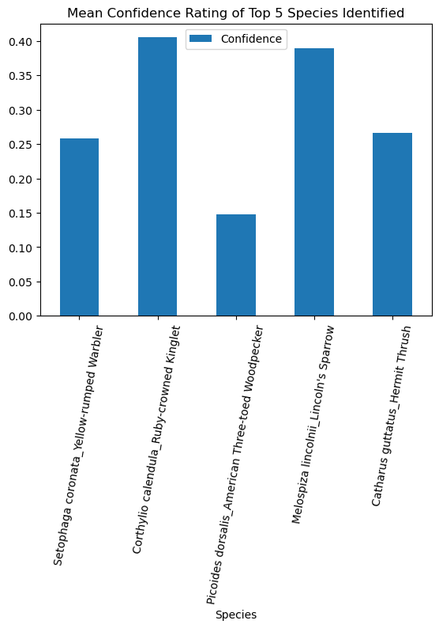

```python
result_summary.head(5).plot.bar(y='Confidence',rot=80,
            title='Mean Confidence Rating of Top 5 Species Identified')
```

Shown here are the top five species identified from the audio files by count: The Yellow-rumbed Warbler, Ruby-crowned Kinglet, American Three-toed Woodpecker, Lincoln's Sparrow, and Hermit Thrush. The bar represents the average confidence rating of the ID by BirdNET. The confidence rating represents the likelihood of the species being present within the corresponding time interval. So even though the Yellow-rumped Warbler had more hits overall, the Ruby-crowned Kinglet was more confidently identified.

### Next Steps

Next steps for the project are to combine the BirdNET results with recording site metadata and export it to a CSV file. Fortunately, that metadata can be obtained from the file name. I would also like to make adjustments to how I run the BirdNET analysis so that confidence values less than 0.50 are dropped. This value was relayed to me by the research partner. Afterwards, I plan to work with the research partner to ensure that the workflow works on their machine and can support them for all future field seasons. At that point, my main objective will be complete, and I can look to creating a preliminary data summary from the complete CSV file.

#### Acknowledgements

This project is in cooperation with Leah McTigue, Ecological Research Associate at Colorado State University, and Zachary Steel PhD, Research Biological Scientist at US Forest Service.

#### References:

Kahl, Stefan and Wood, Connor M and Eibl, Maximilian and Klinck, Holger. BirdNET: A deep learning solution for avian diversity monitoring. Ecological Informatics 61, no. 101236 (2021). Elsevier.

Latif, Quresh S., Jamie S. Sanderlin, Victoria A. Saab, William M. Block, and Jonathan G. Dudley. “Avian Relationships with Wildfire at Two Dry Forest Locations with Different Historical Fire Regimes.” Ecosphere 7, no. 5 (2016): e01346. https://doi.org/10.1002/ecs2.1346.

Steel, Zachary L., Alissa M. Fogg, Ryan Burnett, L. Jay Roberts, and Hugh D. Safford. “When Bigger Isn’t Better—Implications of Large High‐severity Wildfire Patches for Avian Diversity and Community Composition.” Edited by Sally Archibald. Diversity and Distributions 28, no. 3 (March 2022): 439–53. https://doi.org/10.1111/ddi.13281.

Tingley, Morgan W., Viviana Ruiz-Gutiérrez, Robert L. Wilkerson, Christine A. Howell, and Rodney B. Siegel. “Pyrodiversity Promotes Avian Diversity over the Decade Following Forest Fire.” Proceedings of the Royal Society B: Biological Sciences 283 (2016). https://doi.org/10.1098/rspb.2016.1703.